COMS W 4111-002  
W4111 - Introduction to Databases, Section 002, Fall 2021  
Take Home Final

# Exam Instructions

## Overview

The Final Exam is worth 30 points out of the semester's total points. There are 10 questions of varying difficulty worth varying points. The amount of points is not necessarily indicative of difficulty/length of the question, but you can use it as a rough guide. The grade for the final is in the range 0-100. We map the score to final point by multiplying by $30 \over 100$.

The Final Exam is open note, open book, open internet. You **may not collaborate** with other students. Posts on EdStem must be made private for you and the instructors only. Any common questions or clarifications will be made by the instructors on the Final Exam pinned thread. Students **are responsible** for monitoring the thread for corrections and clarifications.

You must cite any online sources in the comments Markdown cell for each questions.

## Overview of Questions

1. Written $-$ Core Databases Concepts (10 pts)
2. Relational Algebra (10 pts)
3. SQL Design and Query (10 pts)
4. Neo4j Design and Query Queries (10 pts)
5. MongoDB Design and Query (10 pts)
6. Implementation Scenario 1: Modeling and Implementing [RACI] in a Database (15 pts)
7. Implementation Scenario 2: Data Model Comparisons (20 pts)
8. Impementation Scenario 3: Data Model Transformation (15 pts)

**Note:** I decided to drop the data model comparison to make the exam easier. So, everyone get's a free 20 points. Also, remember that **I never curve down.**

## Submission Information

This exam is **due Sunday, December 19 at 11:59pm ET** to Gradescope. **You may not use Late Days.**

You submit a zip file containing the main Jupyter Notebook (this file), a PDF of this notebook, and several files in the folder. Each questions provides detailed instructions of how to complete the question.

Your PDFs must be high enough resolution that the text is legible. It must be printed onto standard 8.5x11in pages. Any images that you embed MUST be visible in the PDF. Do not use HTML to embed your images or they will not be visible when you export to PDF.

**Failure to meet these formatting specifications will result in a 0**.

As always, respect for the individual is paramount. We will accommodate special circumstances, but we must be notified and discuss in advance.

# Environment Setup and Test

**Note:** If you have already done the environment setup tests and succeeded, you only need to run the cells that:

1. Import `mysql_check`, `neo4j_check` and `mongodb_check`.
2. Run the cells that set the DB connection information (user ID, password, URL, ...) for the various databases.
3. You can go directly to the questions.

## Instructions

This section tests your environment. You **MUST** completely follows and comply with the instructions.

## Implementation Files

- Several of the questions requiring calling databases from Python code. The python code is simple and implements database queries and operations. This complies with the department's guidelines for *non-programming.*
- There is a section for testing access to each of MySQL, MongoDB and Neo4j. You **must** have installed or have access to the databases, and if locally installed the database must be running.

## MySQL

- Download and load the [Classic Models](https://www.mysqltutorial.org/mysql-sample-database.aspx) database into MySQL. The download site provides installation instructions.
- The comments in the code snippets below provide instructions for completing and executing each cell.

```python
# Import the MySQL test and implementation template/helper functions from the local directory.
# You do not need to modify this cell. You only need to implement it.
#
import mysql_check
```

```python
#
# Call the function below to set the user, password and host for your instance of MySQL.
# YOU MUST set the variables to the correct names for instance.
#
db_user = "root"
db_password = "Zyj7725869"
db_host = "localhost"

mysql_check.set_connect_info(db_user, db_password, db_host)
```

```python
#
# Execute the code below. Your answer should be the same as the exampple out.
#
df = mysql_check.test_pymysql()
df
```

|  | Tables_in_classicmodels |
| --- | --- |
| 0 | customers |
| 1 | employees |
| 2 | offices |
| 3 | orderdetails |
| 4 | orders |
| 5 | payments |
| 6 | productlines |
| 7 | products |

```python
#
# Execute the cell below. Your result should match the example.
#
result_df = mysql_check.test_sql_alchemy()
result_df
```

|  | customerNumber | customerName | country |
| --- | --- | --- | --- |
| 0 | 103 | Atelier graphique | France |
| 1 | 119 | La Rochelle Gifts | France |
| 2 | 146 | Saveley & Henriot, Co. | France |
| 3 | 171 | Daedalus Designs Imports | France |
| 4 | 172 | La Corne D'abondance, Co. | France |
| 5 | 209 | Mini Caravy | France |
| 6 | 242 | Alpha Cognac | France |
| 7 | 250 | Lyon Souveniers | France |
| 8 | 256 | Auto Associés & Cie. | France |
| 9 | 350 | Marseille Mini Autos | France |
| 10 | 353 | Reims Collectables | France |
| 11 | 406 | Auto Canal+ Petit | France |

## Neo4j

```python
#
# Run this cell.
#
import neo4j_check
```

```python
#
# Set the neo4j user and password for connecting to your database. The user is probably neo4j.
# You set the password when you created the project and graph.
#
db_user = "neo4j"
db_password = "Zyj7725869"

neo4j_check.set_neo4j_connect_info(db_user, db_password)
```

```python
#
# You database MUST have the Movie DB installed. You had to do this for HW3. Running this cell should produce
# the sample output.
#
res = neo4j_check.get_people_in_matrix()
res
```

|  | name | born |
| --- | --- | --- |
| 0 | Keanu Reeves | 1964 |
| 1 | Emil Eifrem | 1978 |
| 2 | Carrie-Anne Moss | 1967 |
| 3 | Hugo Weaving | 1960 |
| 4 | Laurence Fishburne | 1961 |

## MongoDB

```python
# Import the MongoDB test and helper functions.
#
import mongodb_check
```

```python
#
# Set the connection URL to get to your instance of MongoDB. You have used this URL
# in HW3 and when using Mongo Compass.
#
connect_url = "mongodb://localhost:27017/"
mongodb_check.set_connect_url(connect_url)
```

```python
#
# Run the following function. This will load information into MongoDB and test the loading.
#
df = mongodb_check.load_and_test_mongo()
df
```

|  | _id | customerNumber | customerName | country |
| --- | --- | --- | --- | --- |
| 0 | 61b6a499b2283066b3199b9c | 103 | Atelier graphique | France |
| 1 | 61b6a499b2283066b3199b9f | 119 | La Rochelle Gifts | France |
| 2 | 61b6a499b2283066b3199ba9 | 146 | Saveley & Henriot, Co. | France |
| 3 | 61b6a499b2283066b3199bb2 | 171 | Daedalus Designs Imports | France |
| 4 | 61b6a499b2283066b3199bb3 | 172 | La Corne D'abondance, Co. | France |
| 5 | 61b6a499b2283066b3199bc1 | 209 | Mini Caravy | France |
| 6 | 61b6a499b2283066b3199bcb | 242 | Alpha Cognac | France |
| 7 | 61b6a499b2283066b3199bce | 250 | Lyon Souveniers | France |
| 8 | 61b6a499b2283066b3199bcf | 256 | Auto Associ茅s & Cie. | France |
| 9 | 61b6a499b2283066b3199beb | 350 | Marseille Mini Autos | France |
| 10 | 61b6a499b2283066b3199bec | 353 | Reims Collectables | France |
| 11 | 61b6a499b2283066b3199bfa | 406 | Auto Canal+ Petit | France |

# 1. Database Core Concepts (10 points)

- There is a [Google Doc](https://docs.google.com/document/d/1b0VVAS_LC25iMjIBx9zP9UhDg5eqsVoQ6h6Wdb68KwQ/edit?usp=sharing).
- Make a copy of the Google Doc. Answer the questions in the document. You will submit a PDF of the document and your answers in the zip file you submit. The file must be in the folder and name **question1.pdf.**

# 2. Relational Algebra

## Instructions

You will use the online relational calculator to answer some of the subquestions. For these questions, your answer must contain:

- The text of the relational statement. The TAs may cut, paste and run the statement and it must work.
- An image showing the results of your execution.
- There is an example below.

## Example

**Question**

- Use the "Silberschatz - UniversityDB" for this question.
- Professor Wu taught only one section. Produce the following information for the section.

| instructor.name | course.title | course.course_id | teaches.semester | teaches.year |
| --- | --- | --- | --- | --- |
| 'Wu' | 'Investment Banking' | 'FIN-201' | 'Spring' | 2010 |

**Answer**

```
π name, title, course_id, semester, year
    (course ⨝ (σ name='Wu' (instructor ⨝ (teaches ⨝ section))))
```

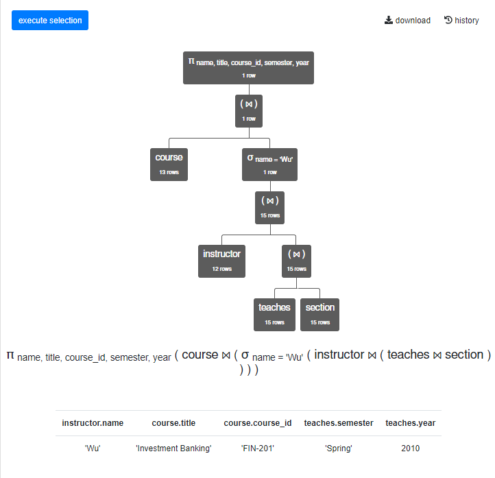

## 2.1 Relation Model Schema (2 points)

**Question**

- The following is a simple MySQL table definition.

```
CREATE TABLE `new_table` (
  `product_category` INT NOT NULL,
  `produce_code` VARCHAR(45) NOT NULL,
  `product_name` VARCHAR(45) NULL,
  `product_description` VARCHAR(45) NULL,
  PRIMARY KEY (`product_category`, `produce_code`));
```

- Using the notation from chapter 2 slides for defining a relational schema, provide the corresponding relation schema definition.
  - Ignore the column types, `NOT NULL`, etc.
  - Two under-bar text, you can use `$\underline{cat}$` to produce $\underline{cat}$.

**Answer** (In Markdown cell below)

new_table($\underline{product\_category}$,$\underline{produce\_code}$,product_name,product_description)

## 2.2 Relational Algebra (4 points)

**Question**

- Provide your answer following the examples' format.
- Use the RelaX calculator the "Silberschatz - UniversityDB" for this question.
- A section `r` overlaps with another section `l` if and only if: They occured at the same time (`year`, `semester`, `time_salot_id`).
- Produce the following table that shows the overlapping sections.

| r.title | r.course_id | r.sec_id | l.title | l.course_id | l.sec_id | l.year | l.semester | l.time_slot_id |
| --- | --- | --- | --- | --- | --- | --- | --- | --- |
| 'Image Processing' | 'CS-319' | 2 | 'World History' | 'HIS-351' | 1 | 2010 | 'Spring' | 'C' |

**Answer**

**Answer**

```
r = ρ r (section ⨝ course)
l = ρ l (section ⨝ course)
M = π r.title,r.course_id,r.sec_id,l.title,l.course_id,l.sec_id,l.year,l.semester,l.time_slot_id ( σ r.course_id ≠ l.course_id ∧ r.year=l.year ∧ r.semester=l.semester ∧ r.time_slot_id=l.time_slot_id ∧ r.course_id>l.course_id ( r ⨯ l ))
M
```

[figure not shown]

## 2.3 Relational Algebra (4 points)

**Question**

- The relation algebra has additional operators for ordering, aggregation/group by, etc.
- A simple analysis of the data in the data in "Silberschatz - UniversityDB" shows that the `takes` table must be incomplete. Produce the following table, where `sum_of_credits` is the sum of a student's credits based on the information in `takes.`

| student_ID | student_name | sum_of_taken_credits | student.tot_cred |
| --- | --- | --- | --- |
| 76653 | 'Aoi' | 3 | 60 |
| 19991 | 'Brandt' | 3 | 80 |
| 76543 | 'Brown' | 7 | 58 |
| 23121 | 'Chavez' | 3 | 110 |
| 44553 | 'Peltier' | 4 | 56 |
| 55739 | 'Sanchez' | 3 | 38 |
| 12345 | 'Shankar' | 14 | 32 |
| 98988 | 'Tanaka' | 8 | 120 |
| 54321 | 'Williams' | 8 | 54 |
| 128 | 'Zhang' | 7 | 102 |

**Answer**

**Answer**

```
X = ρ student_ID←student.ID,student_name←student.name (π student.ID,student.name,course.credits,student.tot_cred,takes.semester,takes.year ((student ⨝ takes) ⨝ course))
Y = γ student_ID,student_name,student.tot_cred;sum(course.credits)→sum_of_taken_credits (X)
Z = τ student_name asc (π student_ID,student_name,sum_of_taken_credits,student.tot_cred (Y))
Z
```

[figure not shown]

# 3. SQL Query

## Instructions and Example

**You must follow and comply with the instructions for completing the questions in this section. Any deviation from the format is a score of 0.**

1. The zip file you downloaded contains a file `question_2_sql.py`. The file contains:
   - An example of the format and approach to answers.
   - An empty function for each answer. You answer the question by completing the function's implementation.
1. The sample returns a Pandas data frame with `customerNumber, customerName and Country.` The country is a parameter to the function call.

```python
import question_3_sql
```

```python
#
# Call the function with the parameter France and display the resulting data frame.
#
result = question_3_sql.question_3_example_get_customers('France')
result
```

|  | customerNumber | customerName | country |
| --- | --- | --- | --- |
| 0 | 103 | Atelier graphique | France |
| 1 | 119 | La Rochelle Gifts | France |
| 2 | 146 | Saveley & Henriot, Co. | France |
| 3 | 171 | Daedalus Designs Imports | France |
| 4 | 172 | La Corne D'abondance, Co. | France |
| 5 | 209 | Mini Caravy | France |
| 6 | 242 | Alpha Cognac | France |
| 7 | 250 | Lyon Souveniers | France |
| 8 | 256 | Auto Associés & Cie. | France |
| 9 | 350 | Marseille Mini Autos | France |
| 10 | 353 | Reims Collectables | France |
| 11 | 406 | Auto Canal+ Petit | France |

## 3.1 Revenue by Country (2 points)

**Question**

1. An `order` is a a set of `orderdetails.`
2. The value/revenue for an `orderdetails` is `priceEach*quantityOrdered`
3. The value/revenue for an `order` is the sum of the value/revenue of the `orderdetails.`
- Implement the function `revenue_by_country`. We provide an example for the output. The company can only claim revenue if the order has `shipped.`

**Answer**

```python
result = question_3_sql.question_3_revenue_by_country()
result
```

|  | revenue | country |
| --- | --- | --- |
| 0 | 3032204.26 | USA |
| 1 | 196470.99 | Germany |
| 2 | 270846.30 | Norway |
| 3 | 947470.01 | Spain |
| 4 | 176791.44 | Denmark |
| 5 | 360616.81 | Italy |
| 6 | 87468.30 | Philippines |
| 7 | 391503.90 | UK |
| 8 | 120457.09 | Sweden |
| 9 | 965750.58 | France |
| 10 | 91471.03 | Belgium |
| 11 | 263997.78 | Singapore |
| 12 | 161418.16 | Austria |
| 13 | 509385.82 | Australia |
| 14 | 416114.03 | New Zealand |
| 15 | 295149.35 | Finland |
| 16 | 205911.86 | Canada |
| 17 | 45480.79 | Hong Kong |
| 18 | 167909.95 | Japan |
| 19 | 49898.27 | Ireland |
| 20 | 108777.92 | Switzerland |

## 3.2 Customer Payments and Customer Purchases (2 points)

**Question**

1. `classicmodels.payments` records customer payments.
2. You can use the the formula above for computing the cost of an order.
3. The total owed by a customer is the total value/revenue for all orders. For the purposes of this problem, you should include all orders and not just the ones that shipped.
4. Implement the functions `purchases_and_payments.` The function returns a data frame with the following columns.
   - `customerNumber`
   - `customerName`
   - `total_spent` is the total value/cost over all orders by the customer.
   - `total_payments` is the total paid by the customer over all payments.
   - `total_unpaid` is the difference between `total_spent` and `total_payments.`
5. Order the result by `customerName.`
6. You must use at least one sub-query in your answer.

**Answer**

```python
#
# Execute this cell to display your answer.
#
result = question_3_sql.question_3_purchases_and_payments()
result
```

|  | customerNumber | customerName | total_spent | total_payments | total_unpaid |
| --- | --- | --- | --- | --- | --- |
| 0 | 242 | Alpha Cognac | 60483.36 | 60483.36 | 0.00 |
| 1 | 168 | American Souvenirs Inc | 0.00 | 0.00 | 0.00 |
| 2 | 249 | Amica Models & Co. | 82223.23 | 82223.23 | 0.00 |
| 3 | 237 | ANG Resellers | 0.00 | 0.00 | 0.00 |
| 4 | 276 | Anna's Decorations, Ltd | 137034.22 | 137034.22 | 0.00 |
| ... | ... | ... | ... | ... | ... |
| 117 | 298 | Vida Sport, Ltd | 108777.92 | 108777.92 | 0.00 |
| 118 | 181 | Vitachrome Inc. | 72497.64 | 72497.64 | 0.00 |
| 119 | 144 | Volvo Model Replicas, Co | 66694.82 | 43680.65 | 23014.17 |
| 120 | 459 | Warburg Exchange | 0.00 | 0.00 | 0.00 |
| 121 | 475 | West Coast Collectables Co. | 43748.72 | 43748.72 | 0.00 |

122 rows × 5 columns

## 3.3 What Customers Buy What? (1 point)

**Question**

1. `Products` are in `productLines.`
2. Product a table that contains the `customerNumber` and `customerName` for all customers that have not orders a product from line `Planes` and not ordered a product from line `Trucks and Buses.`

**Answer**

```python
#
# Run the cell below.
#
result = question_3_sql.question_3_customers_and_lines()
result
```

|  | customerNumber | customerName |
| --- | --- | --- |
| 0 | 103 | Atelier graphique |
| 1 | 112 | Signal Gift Stores |
| 2 | 125 | Havel & Zbyszek Co |
| 3 | 168 | American Souvenirs Inc |
| 4 | 169 | Porto Imports Co. |
| 5 | 171 | Daedalus Designs Imports |
| 6 | 187 | AV Stores, Co. |
| 7 | 201 | UK Collectables, Ltd. |
| 8 | 204 | Online Mini Collectables |
| 9 | 206 | Asian Shopping Network, Co |
| 10 | 209 | Mini Caravy |
| 11 | 219 | Boards & Toys Co. |
| 12 | 223 | Natürlich Autos |
| 13 | 237 | ANG Resellers |
| 14 | 247 | Messner Shopping Network |
| 15 | 259 | Toms Spezialitäten, Ltd |
| 16 | 273 | Franken Gifts, Co |
| 17 | 293 | BG&E Collectables |
| 18 | 298 | Vida Sport, Ltd |
| 19 | 303 | Schuyler Imports |
| 20 | 307 | Der Hund Imports |
| 21 | 314 | Petit Auto |
| 22 | 335 | Cramer Spezialitäten, Ltd |
| 23 | 344 | CAF Imports |
| 24 | 348 | Asian Treasures, Inc. |
| 25 | 350 | Marseille Mini Autos |
| 26 | 356 | SAR Distributors, Co |
| 27 | 357 | GiftsForHim.com |
| 28 | 361 | Kommission Auto |
| 29 | 362 | Gifts4AllAges.com |
| 30 | 369 | Lisboa Souveniers, Inc |
| 31 | 376 | Precious Collectables |
| 32 | 406 | Auto Canal+ Petit |
| 33 | 409 | Stuttgart Collectable Exchange |
| 34 | 443 | Feuer Online Stores, Inc |
| 35 | 456 | Microscale Inc. |
| 36 | 459 | Warburg Exchange |
| 37 | 465 | Anton Designs, Ltd. |
| 38 | 477 | Mit Vergnügen & Co. |
| 39 | 480 | Kremlin Collectables, Co. |
| 40 | 481 | Raanan Stores, Inc |
| 41 | 486 | Motor Mint Distributors Inc. |

# 4 MongoDB

## Instructions and Example

**You must follow and comply with the instructions for completing the questions in this section. Any deviation from the format is a score of 0.**

```python
import question_4_mongo
```

```python
result = question_4_mongo.question_4_example()
result
```

|  | seasonNum | episodeNum | sceneNum | characterName |
| --- | --- | --- | --- | --- |
| 0 | 1 | 1 | 1 | Gared |
| 1 | 1 | 1 | 1 | Waymar Royce |
| 2 | 1 | 1 | 1 | Will |
| 3 | 1 | 1 | 2 | Gared |
| 4 | 1 | 1 | 2 | Waymar Royce |
| ... | ... | ... | ... | ... |
| 148 | 1 | 1 | 35 | Summer |
| 149 | 1 | 1 | 36 | Bran Stark |
| 150 | 1 | 1 | 36 | Summer |
| 151 | 1 | 1 | 36 | Jaime Lannister |
| 152 | 1 | 1 | 36 | Cersei Lannister |

153 rows × 4 columns

## 4.1 Implementing a JOIN (2 points)

**Question**

1. You will need to implement an aggregation for this problem. You can use MongoDB Compass to produce and test the aggregation, and then copy into the implementation template.
2. The aggregation operator `$lookup` implements a join-like function for MongoDB.
3. The aggregation operator (in a project) for getting substrings is `$substr`.
4. Write a query that joins episodes and ratings and produces a list of documents of the form:
   - `seasonNum, episodeNum, episodeTitle, episodeDescription, episodeDate` from `got_episodes.`
   - `tconst, averageRating, numVotes` from title ratings.

**Answer**

```python
#
# Run your test here.
#
result = question_4_mongo.question_4_ratings()
result
```

|  | seasonNum | episodeNum | episodeTitle | episodeDescription | episodeDate | tconst | averageRating | numVotes |
| --- | --- | --- | --- | --- | --- | --- | --- | --- |
| 0 | 1 | 1 | Winter Is Coming | Jon Arryn, the Hand of the King, is dead. King... | 2011-04-17 | tt1480055 | 9.1 | 44596 |
| 1 | 1 | 2 | The Kingsroad | While Bran recovers from his fall, Ned takes o... | 2011-04-24 | tt1668746 | 8.8 | 33936 |
| 2 | 1 | 3 | Lord Snow | Lord Stark and his daughters arrive at King's ... | 2011-05-01 | tt1829962 | 8.7 | 32139 |
| 3 | 1 | 4 | Cripples, Bastards, and Broken Things | Eddard investigates Jon Arryn's murder. Jon be... | 2011-05-08 | tt1829963 | 8.8 | 30562 |
| 4 | 1 | 5 | The Wolf and the Lion | Catelyn has captured Tyrion and plans to bring... | 2011-05-15 | tt1829964 | 9.1 | 31777 |
| ... | ... | ... | ... | ... | ... | ... | ... | ... |
| 68 | 8 | 2 | A Knight of the Seven Kingdoms | The battle at Winterfell is approaching. Jaime... | 2019-04-21 | tt6027908 | 7.8 | 126920 |
| 69 | 8 | 3 | The Long Night | The Night King and his army have arrived at Wi... | 2019-04-28 | tt6027912 | 7.4 | 210187 |
| 70 | 8 | 4 | The Last of the Starks | In the wake of a costly victory, Jon and Daene... | 2019-05-05 | tt6027914 | 5.4 | 160721 |
| 71 | 8 | 5 | The Bells | Daenerys and Cersei weigh their options as an ... | 2019-05-12 | tt6027916 | 5.9 | 187221 |
| 72 | 8 | 6 | The Iron Throne | In the aftermath of the devastating attack on ... | 2019-05-19 | tt6027920 | 4 | 238095 |

73 rows × 8 columns

## 4.2 Just Kidding

- We did not spend a lot of time on MongoDB and that previous query was not fun.
- So, 4.1 is actually with 5 points and you are done with MongoDB. For now.

# 5 Neo4j

## Instructions and Example

**You must follow and comply with the instructions for completing the questions in this section. Any deviation from the format is a score of 0.**

1. You will use the Movie Graph for this question.
2. Implement the answers in functions in the Python file

The example function returns a table with information about which people directed Tom hanks in which movies.

```python
import question_5_neo4j
```

```python
result = question_5_neo4j.directed_tom_hanks()
result
```

|  | 0 | 1 | 2 |
| --- | --- | --- | --- |
| 0 | Tom Hanks | You've Got Mail | Nora Ephron |
| 1 | Tom Hanks | Sleepless in Seattle | Nora Ephron |
| 2 | Tom Hanks | Joe Versus the Volcano | John Patrick Stanley |
| 3 | Tom Hanks | That Thing You Do | Tom Hanks |
| 4 | Tom Hanks | Cloud Atlas | Tom Tykwer |
| 5 | Tom Hanks | Cloud Atlas | Lilly Wachowski |
| 6 | Tom Hanks | Cloud Atlas | Lana Wachowski |
| 7 | Tom Hanks | The Da Vinci Code | Ron Howard |
| 8 | Tom Hanks | The Green Mile | Frank Darabont |
| 9 | Tom Hanks | Apollo 13 | Ron Howard |
| 10 | Tom Hanks | Cast Away | Robert Zemeckis |
| 11 | Tom Hanks | Charlie Wilson's War | Mike Nichols |
| 12 | Tom Hanks | The Polar Express | Robert Zemeckis |
| 13 | Tom Hanks | A League of Their Own | Penny Marshall |

## 5.1 People Who Directed Themseves (2 points)

**Question**

- Implement the function `people_who_directed_themselves.`
- The format of the answer is a data frame of the form `(name, title, name)` where the person `ACTED_IN` and `DRECTED` the movie.

**Answer**

```python
#
# Test you answer
#
result = question_5_neo4j.directed_themselves()
result
```

|  | 0 | 1 | 2 |
| --- | --- | --- | --- |
| 0 | Tom Hanks | That Thing You Do | Tom Hanks |
| 1 | Clint Eastwood | Unforgiven | Clint Eastwood |
| 2 | Danny DeVito | Hoffa | Danny DeVito |

## 5.2 People Who Reviewed the same Movie (3 points)

**Question**

- Implement the function `both_reviewed(person_1_name, person_2_name)`
- The function returns a data frame of the form `person_1_name, movie_title, person_2_name` if the two people with the names rviewed the movie.
- Test you answer with the names below. You cannot hard code names in your query.

**Answer**

```python
#
result = question_5_neo4j.both_reviewed('James Thompson', 'Jessica Thompson')
result
```

|  | 0 | 1 | 2 |
| --- | --- | --- | --- |
| 0 | James Thompson | The Replacements | Jessica Thompson |
| 1 | James Thompson | The Da Vinci Code | Jessica Thompson |

# 6 Data Modeling $-$ RACI

**Question**

- [RACI](https://www.softwareadvice.com/resources/what-is-a-raci-chart/) is an acronym for an approach to defining the relationships between people/stakeholders and a project.
- For this question, you will:
  - Do a Crow's Foot ER diagram defining a data model for representing RACI.
  - Create a SQL schema to represent the tables, constraints, etc. that you determine are necessary.
- The core entity types are:
  - `Project(project_id, project_name, start_date, end_date)`
  - `Person(UNI, last_name, first_name, email)`
- Implementing RACI is about understanding relationships between people and projects. The table below explains the concept.

| Role | Description |
| --- | --- |
| Responsible | Who is responsible for doing the actual work for the project task. |
| Accountable | Who is accountable for the success of the task and is the decision-maker. Typically the project manager.* |
| Consulted | Who needs to be consulted for details and additional info on requirements. Typically the person (or team) to be consulted will be the subject matter expert. |
| Informed | Who needs to be kept informed of major updates. Typically senior leadership. |

- There are two constraints:
  - There is exactly one person who is Accountable for a project.
  - A specific person can have at most one relationship to a project, for example "Bob" cannot be both Consulted and Informed for the same project.
- To answer this question, you must:
  - Draw the Crow's Foot ER diagram using LucidChart.
  - Create a database schema implementing the data model you define.
- You do not need to populate the data model with data or query the data, but YOU MUST execute your DDL statements.
- You execute the DDL statements implementing functions in the file `question_6_schema.`
- You may use DataGrip or other tools to design the schema and test your statements, but for the final answer you most have one function in `question_6_schema` for each DDL statement and you must execute each function in a cell below.
- Name your database schema `RACI.`
- There is no single, correct answer. Document any assumptions or design decisions that you make.

**Design Decisions and Assumptions**

Document any design decisions or assumptions that you make.

- One person can take charge of one or many projects. One project have four people.
- We assume UNI and project_id have data type of char(6) and char(8) since they have the uniform format like "yz3899" for UNI.
- Since a specific person can have at most one relationship to a project. I set triggers to constrain this in relationship table.
- Since the combination of projects and person's UNI is unique, we can set primary key.
- AccountableUNI should be unique, so I set trigger to constrain UNI is not duplicate.

**ER Diagram**

- Put your ER diagram here. You will receive instructions for how to submit on GradeScope.

[figure not shown]

**Schema Creation**

```python
#
#
import question_6_schema
```

```python
#
# Execute each function in a single cell.
#
res = question_6_schema.schema_operation_1()
res
```

```
1
```

```python
#
# Execute each function in a single cell.
#
res = question_6_schema.schema_operation_2()
res
```

```
0
```

```python
#
# Execute each function in a single cell.
#
res = question_6_schema.schema_operation_3()
res
```

```
0
```

```python
#
# Execute each function in a single cell.
#
res = question_6_schema.schema_operation_4()
res
```

```
0
```

```python
#
# Execute each function in a single cell.
#
res = question_6_schema.schema_operation_5()
res
```

```
0
```

```python
#
# Execute each function in a single cell.
#
res = question_6_schema.schema_operation_6()
res
```

```
0
```

```python
#
# Execute each function in a single cell.
#
res = question_6_schema.schema_operation_7()
res
```

```
0
```

```python
#
# Execute each function in a single cell.
#
res = question_6_schema.schema_operation_8()
res
```

```
0
```

# 7. Data Transformation

## Question

**Answer**

In the following cells, execute your various functions that invoke SQL.

**ER Diagram**

[figure not shown]

**Design Decisions and Assumptions**

Document any design decisions or assumptions that you make.

- The new schema's data type is same as classicmodels in general.

```python
#
#
import question_7_sql
```

```python
#
# Execute each function in a single cell.
#
res = question_7_sql.schema_operation_1()
res
```

```
1
```

```python
res = question_7_sql.schema_operation_2()
res
```

```
0
```

```python
res = question_7_sql.schema_operation_3()
res
```

```
0
```

```python
res = question_7_sql.schema_operation_4()
res
```

```
0
```

```python
res = question_7_sql.schema_operation_5()
res
```

```
0
```

```python
res = question_7_sql.data_transformation_1()
res
```

```
265
```

```python
res = question_7_sql.data_transformation_2()
res
```

```
2996
```

```python
res = question_7_sql.data_transformation_3()
res
```

```
67
```

```python
res = question_7_sql.sales_by_year_region()
res
```

|  | sales | region | year |
| --- | --- | --- | --- |
| 0 | 1519511.84 | EMEA | 2003 |
| 1 | 2171244.36 | EMEA | 2004 |
| 2 | 1225638.04 | NA | 2003 |
| 3 | 1649903.68 | NA | 2004 |
| 4 | 572198.51 | AP | 2003 |
| 5 | 694757.47 | AP | 2004 |
| 6 | 829956.08 | EMEA | 2005 |
| 7 | 603650.19 | NA | 2005 |
| 8 | 337330.44 | AP | 2005 |

```python
res = question_7_sql.sales_by_quarter_year_county_region()
res
```

|  | sales | quarter | year | country | region |
| --- | --- | --- | --- | --- | --- |
| 0 | 115479.71 | 2 | 2003 | France | EMEA |
| 1 | 55951.77 | 3 | 2004 | France | EMEA |
| 2 | 220409.99 | 4 | 2004 | France | EMEA |
| 3 | 136218.56 | 2 | 2003 | USA | NA |
| 4 | 369912.42 | 3 | 2004 | USA | NA |
| ... | ... | ... | ... | ... | ... |
| 117 | 27966.54 | 1 | 2005 | Sweden | EMEA |
| 118 | 42252.87 | 4 | 2003 | Austria | EMEA |
| 119 | 8807.12 | 1 | 2005 | Austria | EMEA |
| 120 | 7612.06 | 1 | 2004 | Italy | EMEA |
| 121 | 32077.44 | 3 | 2003 | New Zealand | AP |

122 rows × 5 columns

```python
res = question_7_sql.sales_by_product_line_scale_year()
res
```

|  | sales | productLine | productScale | year |
| --- | --- | --- | --- | --- |
| 0 | 461947.22 | Vintage Cars | 1:18 | 2003 |
| 1 | 127471.05 | Vintage Cars | 1:24 | 2003 |
| 2 | 146538.41 | Classic Cars | 1:10 | 2003 |
| 3 | 78911.11 | Trucks and Buses | 1:12 | 2003 |
| 4 | 149827.91 | Trucks and Buses | 1:18 | 2003 |
| ... | ... | ... | ... | ... |
| 85 | 61905.07 | Planes | 1:700 | 2005 |
| 86 | 34950.65 | Planes | 1:72 | 2005 |
| 87 | 8014.35 | Ships | 1:72 | 2005 |
| 88 | 11663.53 | Vintage Cars | 1:32 | 2005 |
| 89 | 8576.51 | Vintage Cars | 1:50 | 2005 |

90 rows × 4 columns